# Personal Loan Campaign

### Log Transformation

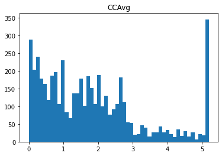

```
106
```

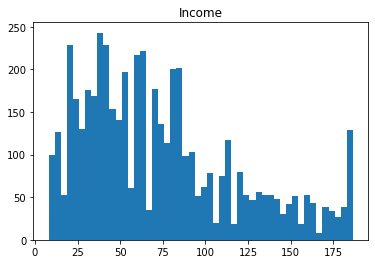

```
0
```

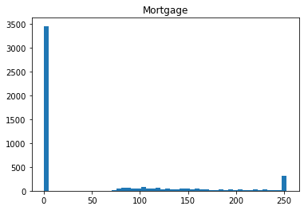

```
3462
```

```python
#CCAvg, Income, Mortgage are rightly skewed. we can see if Log transformation can help

cols_to_log = ['CCAvg', 'Income','Mortgage']
for colname in cols_to_log:
    plt.hist(data[colname], bins=50)
    plt.title(colname)
    plt.show()
    print(np.sum(data[colname] <= 0))
```

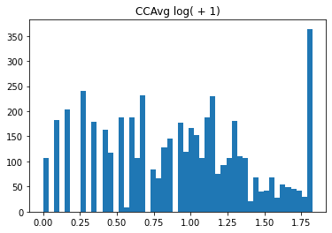

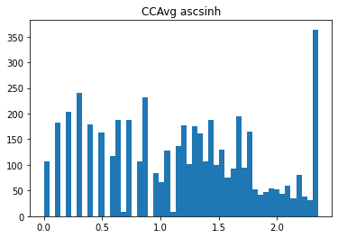

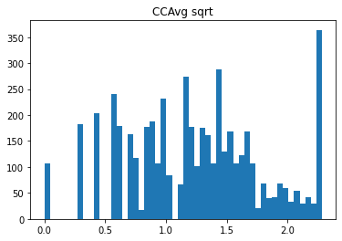

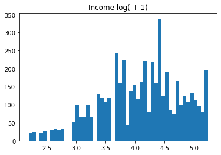

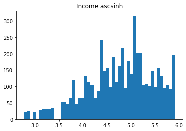

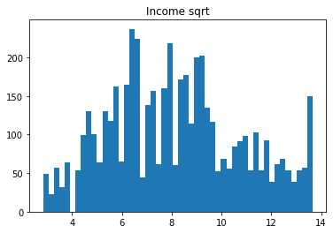

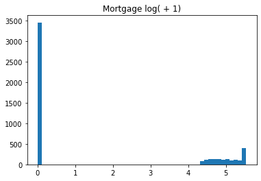

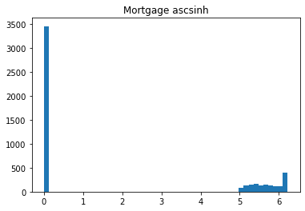

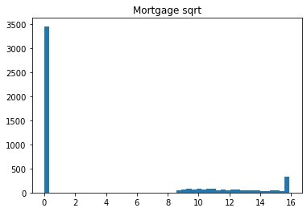

```python
#If there are zeros we cant directly take the log of these numbers. We can try log +1, ascsinh, and sqrt to see which
#works best
for colname in cols_to_log:
    plt.hist(np.log(data[colname] + 1), 50)
    plt.title(colname + ' log( + 1)')
    plt.show()
    plt.hist(np.arcsinh(data[colname]), 50)
    plt.title(colname + ' ascsinh')
    plt.show()
    plt.hist(np.sqrt(data[colname]), 50)
    plt.title(colname + ' sqrt')
    plt.show()
```

```python
#It looks like sqrt worked best for these columns so lets go ahead and update them
for colname in cols_to_log:
    data[colname + '_sqrt'] = np.sqrt(data[colname])
data.drop(cols_to_log, axis=1, inplace=True)
```

```python
data.head()
```

|  | Age | ZIPCode | Family | Education | Personal_Loan | Securities_Account | CD_Account | Online | CreditCard | CCAvg_sqrt | Income_sqrt | Mortgage_sqrt |
| --- | --- | --- | --- | --- | --- | --- | --- | --- | --- | --- | --- | --- |
| 0 | 25 | 91 | 4 | 1 | 0 | 1 | 0 | 0 | 0 | 1.264911 | 7.000000 | 0.0 |
| 1 | 45 | 90 | 3 | 1 | 0 | 1 | 0 | 0 | 0 | 1.224745 | 5.830952 | 0.0 |
| 2 | 39 | 94 | 1 | 1 | 0 | 0 | 0 | 0 | 0 | 1.000000 | 3.316625 | 0.0 |
| 3 | 35 | 94 | 1 | 2 | 0 | 0 | 0 | 0 | 0 | 1.643168 | 10.000000 | 0.0 |
| 4 | 35 | 91 | 4 | 2 | 0 | 0 | 0 | 0 | 1 | 1.000000 | 6.708204 | 0.0 |

### Standardizing continous variables

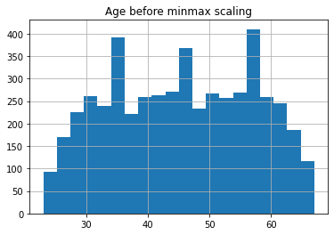

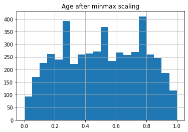

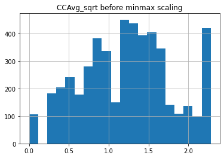

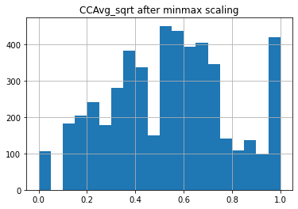

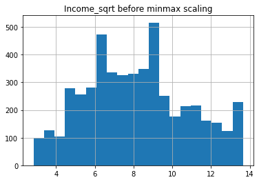

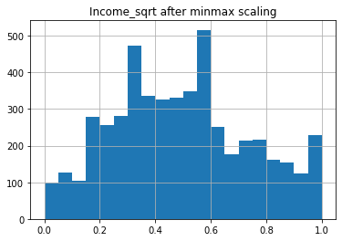

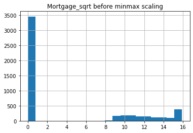

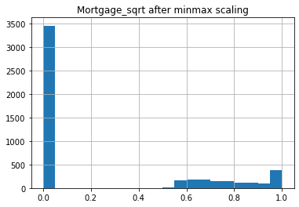

```python
#loop to scale columns

std_scaler = StandardScaler()
cols_to_scale = ['Age', 'CCAvg_sqrt', 'Income_sqrt', 'Mortgage_sqrt']
for colname in cols_to_scale:
    data[colname].hist(bins=20)
    plt.title(colname + ' before minmax scaling')
    plt.show()

    data[[colname]] = MinMaxScaler().fit_transform(
        data[[colname]]
    )

    data[colname].hist(bins=20)
    plt.title(colname + ' after minmax scaling')
    plt.show()
```

The numeric independent variables have been scaled so that we can easily compare their coeffiecients.

### Model metrics for this problem statement

#### What does a bank want?

A bank wants to minimize the loss - it can face 2 types of losses here: Whenever bank lends money to a customer, they don't return that. A bank doesn't lend money to a customer thinking he will default but in reality he won't - oppurtunity loss.

#### Which loss is greater ?

Customer not returning the money back. Since we don't want people to default on the loans we should use Recall as a metric of model evaluation instead of accuracy.

Recall - It gives the ratio of True positives to Actual positives, so high Recall implies low false negatives, i.e. low chances of predicting a defaulter as non defaulter

## Model Building - Logistic Regression

### Creating train and test sets

```python
X = data.drop(["Personal_Loan"], axis=1)
Y = data["Personal_Loan"]

X = pd.get_dummies(X, drop_first=True)

# Splitting data in train and test sets
X_train, X_test, y_train, y_test = train_test_split(
    X, Y, test_size=0.30, random_state=1
)
```

```python
#Print a few rows to ensure that the dummy columns were created
X.head()
```

|  | Age | Securities_Account | CD_Account | Online | CreditCard | CCAvg_sqrt | Income_sqrt | Mortgage_sqrt | ZIPCode_91 | ZIPCode_92 | ZIPCode_93 | ZIPCode_94 | ZIPCode_95 | ZIPCode_96 | Family_2 | Family_3 | Family_4 | Education_2 | Education_3 |
| --- | --- | --- | --- | --- | --- | --- | --- | --- | --- | --- | --- | --- | --- | --- | --- | --- | --- | --- | --- |
| 0 | 0.045455 | 1 | 0 | 0 | 0 | 0.554700 | 0.385255 | 0.0 | 1 | 0 | 0 | 0 | 0 | 0 | 0 | 0 | 1 | 0 | 0 |
| 1 | 0.500000 | 1 | 0 | 0 | 0 | 0.537086 | 0.277291 | 0.0 | 0 | 0 | 0 | 0 | 0 | 0 | 0 | 1 | 0 | 0 | 0 |
| 2 | 0.363636 | 0 | 0 | 0 | 0 | 0.438529 | 0.045086 | 0.0 | 0 | 0 | 0 | 1 | 0 | 0 | 0 | 0 | 0 | 0 | 0 |
| 3 | 0.272727 | 0 | 0 | 0 | 0 | 0.720577 | 0.662313 | 0.0 | 0 | 0 | 0 | 1 | 0 | 0 | 0 | 0 | 0 | 1 | 0 |
| 4 | 0.272727 | 0 | 0 | 0 | 1 | 0.438529 | 0.358307 | 0.0 | 1 | 0 | 0 | 0 | 0 | 0 | 0 | 0 | 1 | 1 | 0 |

```python
print("Shape of Training set : ", X_train.shape)
print("Shape of test set : ", X_test.shape)
print("Percentage of classes in training set:")
print(y_train.value_counts(normalize=True))
print("Percentage of classes in test set:")
print(y_test.value_counts(normalize=True))
```

```
Shape of Training set :  (3500, 19)
Shape of test set :  (1500, 19)
Percentage of classes in training set:
0    0.905429
1    0.094571
Name: Personal_Loan, dtype: float64
Percentage of classes in test set:
0    0.900667
1    0.099333
Name: Personal_Loan, dtype: float64
```

```python
# defining a function to compute different metrics to check performance of a classification model built using sklearn

def model_performance_classification_sklearn_with_threshold(model, predictors, target, threshold=0.5):
    """
    Function to compute different metrics, based on the threshold specified, to check classification model performance

    model: classifier
    predictors: independent variables
    target: dependent variable
    threshold: threshold for classifying the observation as class 1
    """

    # predicting using the independent variables
    pred_prob = model.predict_proba(predictors)[:, 1]
    pred_thres = pred_prob > threshold
    pred = np.round(pred_thres)

    acc = accuracy_score(target, pred)  # to compute Accuracy
    recall = recall_score(target, pred)  # to compute Recall
    precision = precision_score(target, pred)  # to compute Precision
    f1 = f1_score(target, pred)  # to compute F1-score

    # creating a dataframe of metrics
    df_perf = pd.DataFrame(
        {
            "Accuracy": acc,
            "Recall": recall,
            "Precision": precision,
            "F1": f1,
        },
        index=[0],
    )

    return df_perf
```

```python
# defining a function to plot the confusion_matrix of a classification model built using sklearn
def confusion_matrix_sklearn_with_threshold(model, predictors, target, threshold=0.5):
    """
    To plot the confusion_matrix, based on the threshold specified, with percentages

    model: classifier
    predictors: independent variables
    target: dependent variable
    threshold: threshold for classifying the observation as class 1
    """
    pred_prob = model.predict_proba(predictors)[:, 1]
    pred_thres = pred_prob > threshold
    y_pred = np.round(pred_thres)

    cm = confusion_matrix(target, y_pred)
    labels = np.asarray(
        [
            ["{0:0.0f}".format(item) + "\n{0:.2%}".format(item / cm.flatten().sum())]
            for item in cm.flatten()
        ]
    ).reshape(2, 2)

    plt.figure(figsize=(6, 4))
    sns.heatmap(cm, annot=labels, fmt="")
    plt.ylabel("True label")
    plt.xlabel("Predicted label")
```

```python
# There are different solvers available in Sklearn logistic regression
# The newton-cg solver is faster for high-dimensional data

lg = LogisticRegression(solver="newton-cg", random_state=1)
model = lg.fit(X_train, y_train)
```

```python
# let us check the coefficients and intercept of the model

coef_df = pd.DataFrame(
    np.append(lg.coef_, lg.intercept_),
    index=X_train.columns.tolist() + ["Intercept"],
    columns=["Coefficients"],
)
coef_df.sort_values("Coefficients")
```

|  | Coefficients |
| --- | --- |
| Intercept | -12.991515 |
| Securities_Account | -0.783036 |
| CreditCard | -0.770511 |
| ZIPCode_96 | -0.425630 |
| Online | -0.423355 |
| ZIPCode_91 | -0.039939 |
| Family_2 | -0.010391 |
| ZIPCode_95 | 0.011533 |
| ZIPCode_94 | 0.030868 |
| Age | 0.129707 |
| ZIPCode_92 | 0.159518 |
| Mortgage_sqrt | 0.242786 |
| ZIPCode_93 | 0.248607 |
| Family_4 | 1.061512 |
| Family_3 | 1.809134 |
| Education_2 | 2.599011 |
| Education_3 | 2.757752 |
| CD_Account | 2.778495 |
| CCAvg_sqrt | 2.894241 |
| Income_sqrt | 9.686451 |

### Coefficients interpretations

Coefficients of Securities_Account, Credit_Card and ZIPCode 96, Online, ZIPCode_91, Family_2 are negative. Indicating that an increase in these features will lead to a decrease in the customers taking Personal_Loan.

### Checking model performance on training set

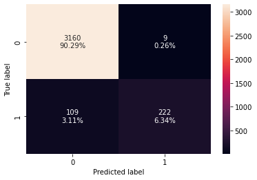

```python
# creating confusion matrix
confusion_matrix_sklearn_with_threshold(lg, X_train, y_train)
```

```python
log_reg_model_train_perf = model_performance_classification_sklearn_with_threshold(
    lg, X_train, y_train
)

print("Training performance:")
log_reg_model_train_perf
```

```
Training performance:
```

|  | Accuracy | Recall | Precision | F1 |
| --- | --- | --- | --- | --- |
| 0 | 0.966286 | 0.670695 | 0.961039 | 0.790036 |

### Checking model performance on test data

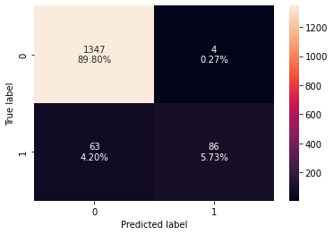

```python
# creating confusion matrix
confusion_matrix_sklearn_with_threshold(lg, X_test, y_test)
```

```python
log_reg_model_test_perf = model_performance_classification_sklearn_with_threshold(
    lg, X_test, y_test
)

print("Test set performance:")
log_reg_model_test_perf
```

```
Test set performance:
```

|  | Accuracy | Recall | Precision | F1 |
| --- | --- | --- | --- | --- |
| 0 | 0.955333 | 0.577181 | 0.955556 | 0.719665 |

### ROC-AUC

#### ROC-AUC on training set

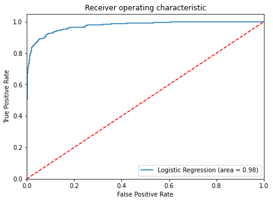

```python
logit_roc_auc_train = roc_auc_score(y_train, lg.predict_proba(X_train)[:, 1])
fpr, tpr, thresholds = roc_curve(y_train, lg.predict_proba(X_train)[:, 1])
plt.figure(figsize=(7, 5))
plt.plot(fpr, tpr, label="Logistic Regression (area = %0.2f)" % logit_roc_auc_train)
plt.plot([0, 1], [0, 1], "r--")
plt.xlim([0.0, 1.0])
plt.ylim([0.0, 1.05])
plt.xlabel("False Positive Rate")
plt.ylabel("True Positive Rate")
plt.title("Receiver operating characteristic")
plt.legend(loc="lower right")
plt.show()
```

#### ROC-AUC on test set

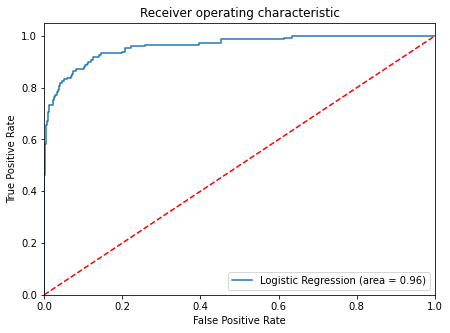

```python
logit_roc_auc_test = roc_auc_score(y_test, lg.predict_proba(X_test)[:, 1])
fpr, tpr, thresholds = roc_curve(y_test, lg.predict_proba(X_test)[:, 1])
plt.figure(figsize=(7, 5))
plt.plot(fpr, tpr, label="Logistic Regression (area = %0.2f)" % logit_roc_auc_test)
plt.plot([0, 1], [0, 1], "r--")
plt.xlim([0.0, 1.0])
plt.ylim([0.0, 1.05])
plt.xlabel("False Positive Rate")
plt.ylabel("True Positive Rate")
plt.title("Receiver operating characteristic")
plt.legend(loc="lower right")
plt.show()
```

Model is giving a generalized performance.

### Model Performance Improvement

#### Let's see if the f1 score can be improved further, by changing the model threshold using AUC-ROC Curve.

Optimal threshold using AUC-ROC curve

```python
# Optimal threshold as per AUC-ROC curve
# The optimal cut off would be where tpr is high and fpr is low
fpr, tpr, thresholds = roc_curve(y_train, lg.predict_proba(X_train)[:, 1])

optimal_idx = np.argmax(tpr - fpr)
optimal_threshold_auc_roc = thresholds[optimal_idx]
print(optimal_threshold_auc_roc)
```

```
0.18303483176602084
```

##### The optimal threshold using AUC-ROC curve is 0.18

#### Checking model performance on training set

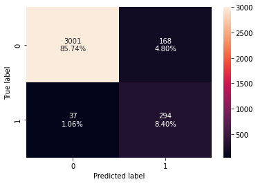

```python
# creating confusion matrix
confusion_matrix_sklearn_with_threshold(
    lg, X_train, y_train, threshold=optimal_threshold_auc_roc
)
```

```python
# checking model performance for this model
log_reg_model_train_perf_threshold_auc_roc = model_performance_classification_sklearn_with_threshold(
    lg, X_train, y_train, threshold=optimal_threshold_auc_roc
)
print("Training performance:")
log_reg_model_train_perf_threshold_auc_roc
```

```
Training performance:
```

|  | Accuracy | Recall | Precision | F1 |
| --- | --- | --- | --- | --- |
| 0 | 0.941429 | 0.888218 | 0.636364 | 0.741488 |

#### Checking model performance on test set

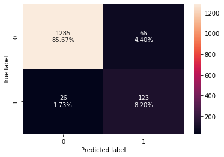

```python
# creating confusion matrix
confusion_matrix_sklearn_with_threshold(
    lg, X_test, y_test, threshold=optimal_threshold_auc_roc
)
```

```python
# checking model performance for this model
log_reg_model_test_perf_threshold_auc_roc = model_performance_classification_sklearn_with_threshold(
    lg, X_test, y_test, threshold=optimal_threshold_auc_roc
)
print("Test set performance:")
log_reg_model_test_perf_threshold_auc_roc
```

```
Test set performance:
```

|  | Accuracy | Recall | Precision | F1 |
| --- | --- | --- | --- | --- |
| 0 | 0.938667 | 0.825503 | 0.650794 | 0.727811 |

#### Let's use Precision-Recall curve and see if we can find a better threshold

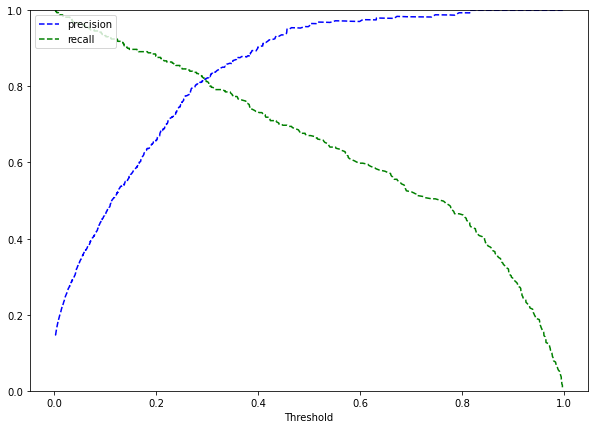

```python
y_scores = lg.predict_proba(X_train)[:, 1]
prec, rec, tre = precision_recall_curve(y_train, y_scores,)


def plot_prec_recall_vs_tresh(precisions, recalls, thresholds):
    plt.plot(thresholds, precisions[:-1], "b--", label="precision")
    plt.plot(thresholds, recalls[:-1], "g--", label="recall")
    plt.xlabel("Threshold")
    plt.legend(loc="upper left")
    plt.ylim([0, 1])


plt.figure(figsize=(10, 7))
plot_prec_recall_vs_tresh(prec, rec, tre)
plt.show()
```

At the Threshold 0f 0.3, we get balanced recall and precision score.

```python
# setting the threshold
optimal_threshold_curve = 0.3
```

#### Checking model performance on training set

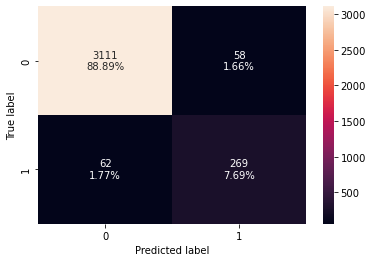

```python
# creating confusion matrix
confusion_matrix_sklearn_with_threshold(
    lg, X_train, y_train, threshold=optimal_threshold_curve
)
```

```python
log_reg_model_train_perf_threshold_curve = model_performance_classification_sklearn_with_threshold(
    lg, X_train, y_train, threshold=optimal_threshold_curve
)
print("Training performance:")
log_reg_model_train_perf_threshold_curve
```

```
Training performance:
```

|  | Accuracy | Recall | Precision | F1 |
| --- | --- | --- | --- | --- |
| 0 | 0.965714 | 0.812689 | 0.82263 | 0.817629 |

#### Checking model performance on test set

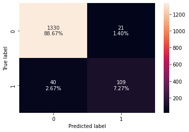

```python
# creating confusion matrix
confusion_matrix_sklearn_with_threshold(
    lg, X_test, y_test, threshold=optimal_threshold_curve
)
```

```python
log_reg_model_test_perf_threshold_curve = model_performance_classification_sklearn_with_threshold(
    lg, X_test, y_test, threshold=optimal_threshold_curve
)
print("Test set performance:")
log_reg_model_test_perf_threshold_curve
```

```
Test set performance:
```

|  | Accuracy | Recall | Precision | F1 |
| --- | --- | --- | --- | --- |
| 0 | 0.959333 | 0.731544 | 0.838462 | 0.781362 |

Since for this problem we are interested in Recall, and the Recall decreased so this is not the best model.

### Model Performance Summary

```python
# training performance comparison

models_train_comp_df = pd.concat(
    [
        log_reg_model_train_perf.T,
        log_reg_model_train_perf_threshold_auc_roc.T,
        log_reg_model_train_perf_threshold_curve.T
    ],
    axis=1,
)
models_train_comp_df.columns = [
    "Logistic Regression sklearn",
    "Logistic Regression-0.18 Threshold",
    "Logistic Regression-0.30 Threshold"
]
print("Training performance comparison:")
models_train_comp_df
```

```
Training performance comparison:
```

|  | Logistic Regression sklearn | Logistic Regression-0.18 Threshold | Logistic Regression-0.30 Threshold |
| --- | --- | --- | --- |
| Accuracy | 0.966286 | 0.941429 | 0.965714 |
| Recall | 0.670695 | 0.888218 | 0.812689 |
| Precision | 0.961039 | 0.636364 | 0.822630 |
| F1 | 0.790036 | 0.741488 | 0.817629 |

```python
# testing performance comparison

models_test_comp_df = pd.concat(
    [
        log_reg_model_test_perf.T,
        log_reg_model_test_perf_threshold_auc_roc.T,
        log_reg_model_test_perf_threshold_curve.T
        ],
    axis=1,
)
models_test_comp_df.columns = [
    "Logistic Regression sklearn",
    "Logistic Regression-0.18 Threshold",
    "Logistic Regression-0.30 Threshold"
]
print("Test set performance comparison:")
models_test_comp_df
```

```
Test set performance comparison:
```

|  | Logistic Regression sklearn | Logistic Regression-0.18 Threshold | Logistic Regression-0.30 Threshold |
| --- | --- | --- | --- |
| Accuracy | 0.955333 | 0.938667 | 0.959333 |
| Recall | 0.577181 | 0.825503 | 0.731544 |
| Precision | 0.955556 | 0.650794 | 0.838462 |
| F1 | 0.719665 | 0.727811 | 0.781362 |

### Summary and recommendation for Logistic Regression model

The f1 score is best with the model that has a 0.3 threshold. However for this problem we are interested in Recall. So the model with the threshold of 0.18 gave the best Recall and would be considered the best model.

Coefficients of Securities_Account, Credit_Card and ZIPCode 96, Online, ZIPCode_91, Family_2 are negative. Indicating that an increase in these features will lead to a decrease in the customers taking Personal_Loan.

## Model Building - Decision Trees

### Define independent and dependent variables

```python
X = data.drop("Personal_Loan" , axis=1)
y = data.pop("Personal_Loan")
```

### Creating dummy variables

```python
X = pd.get_dummies(
    X,
    columns=X.select_dtypes(include=["category"]).columns.tolist(),
    drop_first=False,
)
X.head()
```

|  | Age | Securities_Account | CD_Account | Online | CreditCard | CCAvg_sqrt | Income_sqrt | Mortgage_sqrt | ZIPCode_90 | ZIPCode_91 | ZIPCode_92 | ZIPCode_93 | ZIPCode_94 | ZIPCode_95 | ZIPCode_96 | Family_1 | Family_2 | Family_3 | Family_4 | Education_1 | Education_2 | Education_3 |
| --- | --- | --- | --- | --- | --- | --- | --- | --- | --- | --- | --- | --- | --- | --- | --- | --- | --- | --- | --- | --- | --- | --- |
| 0 | 0.045455 | 1 | 0 | 0 | 0 | 0.554700 | 0.385255 | 0.0 | 0 | 1 | 0 | 0 | 0 | 0 | 0 | 0 | 0 | 0 | 1 | 1 | 0 | 0 |
| 1 | 0.500000 | 1 | 0 | 0 | 0 | 0.537086 | 0.277291 | 0.0 | 1 | 0 | 0 | 0 | 0 | 0 | 0 | 0 | 0 | 1 | 0 | 1 | 0 | 0 |
| 2 | 0.363636 | 0 | 0 | 0 | 0 | 0.438529 | 0.045086 | 0.0 | 0 | 0 | 0 | 0 | 1 | 0 | 0 | 1 | 0 | 0 | 0 | 1 | 0 | 0 |
| 3 | 0.272727 | 0 | 0 | 0 | 0 | 0.720577 | 0.662313 | 0.0 | 0 | 0 | 0 | 0 | 1 | 0 | 0 | 1 | 0 | 0 | 0 | 0 | 1 | 0 |
| 4 | 0.272727 | 0 | 0 | 0 | 1 | 0.438529 | 0.358307 | 0.0 | 0 | 1 | 0 | 0 | 0 | 0 | 0 | 0 | 0 | 0 | 1 | 0 | 1 | 0 |

### Split the data

```python
X_train, X_test, y_train, y_test = train_test_split(X, y, test_size=.30, random_state=1)
```

### Build Decision Tree Model

We will build our model using the DecisionTreeClassifier function. Using default 'gini' criteria to split. Other option include 'entropy'.

```python
dTree = DecisionTreeClassifier(criterion = 'gini', random_state=1)
dTree.fit(X_train, y_train)
```

```
DecisionTreeClassifier(random_state=1)
```

### Scoring our Decision Tree

```python
print("Accuracy on training set : ",dTree.score(X_train, y_train))
print("Accuracy on test set : ",dTree.score(X_test, y_test))
```

```
Accuracy on training set :  1.0
Accuracy on test set :  0.9793333333333333
```

```python
#Checking number of positives
y.sum(axis = 0)
```

```
480
```

```python
## Function to create confusion matrix
def make_confusion_matrix(model,y_actual,labels=[1, 0]):
    '''
    model : classifier to predict values of X
    y_actual : ground truth

    '''
    y_predict = model.predict(X_test)
    cm=metrics.confusion_matrix( y_actual, y_predict, labels=[0, 1])
    df_cm = pd.DataFrame(cm, index = [i for i in ["Actual - No","Actual - Yes"]],
                  columns = [i for i in ['Predicted - No','Predicted - Yes']])
    group_counts = ["{0:0.0f}".format(value) for value in
                cm.flatten()]
    group_percentages = ["{0:.2%}".format(value) for value in
                         cm.flatten()/np.sum(cm)]
    labels = [f"{v1}\n{v2}" for v1, v2 in
              zip(group_counts,group_percentages)]
    labels = np.asarray(labels).reshape(2,2)
    plt.figure(figsize = (10,7))
    sns.heatmap(df_cm, annot=labels,fmt='')
    plt.ylabel('True label')
    plt.xlabel('Predicted label')
```

```python
##  Function to calculate recall score
def get_recall_score(model):
    '''
    model : classifier to predict values of X

    '''
    pred_train = model.predict(X_train)
    pred_test = model.predict(X_test)
    print("Recall on training set : ",metrics.recall_score(y_train,pred_train))
    print("Recall on test set : ",metrics.recall_score(y_test,pred_test))
```

### Confusion Matrix

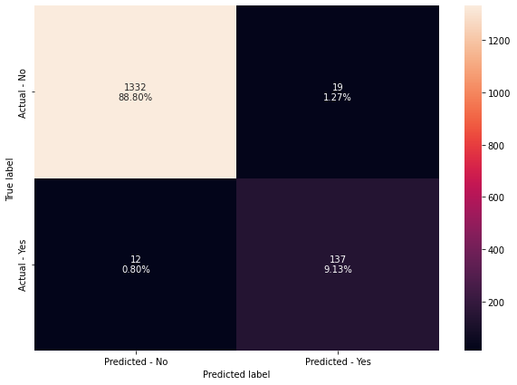

```python
make_confusion_matrix(dTree,y_test)
```

```python
# Recall on train and test
get_recall_score(dTree)
```

```
Recall on training set :  1.0
Recall on test set :  0.9194630872483222
```

### Visualizing the Decision Tree with full built tree

```python
feature_names = list(X.columns)
print(feature_names)
```

```
['Age', 'Securities_Account', 'CD_Account', 'Online', 'CreditCard', 'CCAvg_sqrt', 'Income_sqrt', 'Mortgage_sqrt', 'ZIPCode_90', 'ZIPCode_91', 'ZIPCode_92', 'ZIPCode_93', 'ZIPCode_94', 'ZIPCode_95', 'ZIPCode_96', 'Family_1', 'Family_2', 'Family_3', 'Family_4', 'Education_1', 'Education_2', 'Education…
```

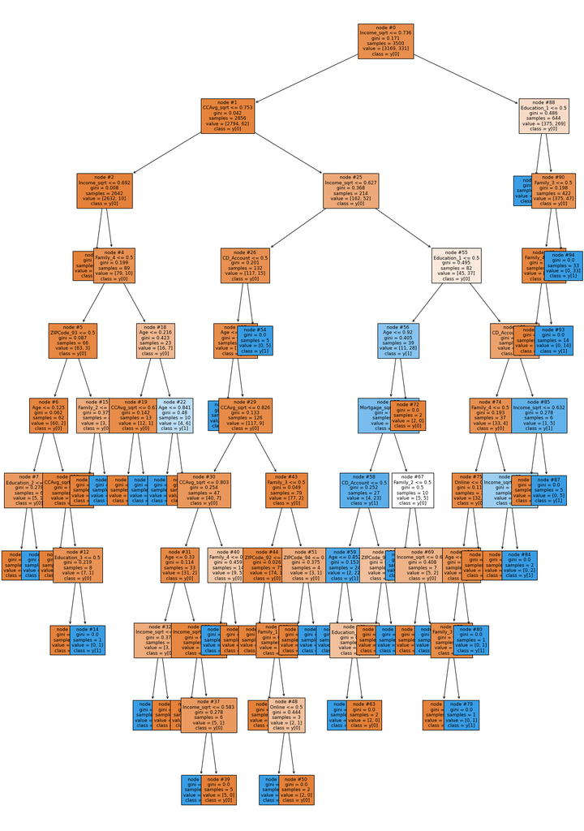

```python
plt.figure(figsize=(20,30))
tree.plot_tree(dTree,feature_names=feature_names,filled=True,fontsize=9,node_ids=True,class_names=True)
plt.show()
```

```python
# Text report showing the rules of a decision tree -

print(tree.export_text(dTree,feature_names=feature_names,show_weights=True))
```

```
|--- Income_sqrt <= 0.74
|   |--- CCAvg_sqrt <= 0.75
|   |   |--- Income_sqrt <= 0.69
|   |   |   |--- weights: [2553.00, 0.00] class: 0
|   |   |--- Income_sqrt >  0.69
|   |   |   |--- Family_4 <= 0.50
|   |   |   |   |--- ZIPCode_93 <= 0.50
|   |   |   |   |   |--- Age <= 0.13
|   |   |   |   |   |   |--- Education_2 <= 0.50
|   |   |   |   |   |   |   |--- weights: [5.00, 0.00] class: 0
|   |   |   |   |   |   |--- Education_2 >  0.50
|   |   |   |   |   |   |   |--- weights: [0.00, 1.00] class: 1
|   |   |   |   |   |--- Age >  0.13
|   |   |   |   |   |   |--- CCAvg_sqrt <= 0.65
|   |   |   |   |   |   |   |--- weights: [48.00, 0.00] class: 0
|   |   |   |   |   |   |--- CCAvg_sqrt >  0.65
|   |   |   |   |   |   |   |--- Education_3 <= 0.50
|   |   |   |   |   |   |   |   |--- weights: [7.00, 0.00] class: 0
|   |   |   |   |   |   |   |--- Education_3 >  0.50
|   |   |   |   |   |   |   |   |--- weights: [0.00, 1.00] class: 1
|   |   |   |   |--- ZIPCode_93 >  0.50
|   |   |   |   |   |--- Family_2 <= 0.50
|   |   |   |   |   |   |--- weights: [3.00, 0.00] class: 0
|   |   |   |   |   |--- Family_2 >  0.50
|   |   |   |   |   |   |--- weights: [0.00, 1.00] class: 1
|   |   |   |--- Family_4 >  0.50
|   |   |   |   |--- Age <= 0.22
|   |   |   |   |   |--- CCAvg_sqrt <= 0.68
|   |   |   |   |   |   |--- weights: [12.00, 0.00] class: 0
|   |   |   |   |   |--- CCAvg_sqrt >  0.68
|   |   |   |   |   |   |--- weights: [0.00, 1.00] class: 1
|   |   |   |   |--- Age >  0.22
|   |   |   |   |   |--- Age <= 0.84
|   |   |   |   |   |   |--- weights: [0.00, 6.00] class: 1
|   |   |   |   |   |--- Age >  0.84
|   |   |   |   |   |   |--- weights: [4.00, 0.00] class: 0
|   |--- CCAvg_sqrt >  0.75
|   |   |--- Income_sqrt <= 0.63
|   |   |   |--- CD_Account <= 0.50
|   |   |   |   |--- Age <= 0.08
```

[output cut: 87 more lines]

```
|   |   |   |   |   |--- Income_sqrt <= 0.63
|   |   |   |   |   |   |--- weights: [1.00, 0.00] class: 0
|   |   |   |   |   |--- Income_sqrt >  0.63
|   |   |   |   |   |   |--- weights: [0.00, 5.00] class: 1
|--- Income_sqrt >  0.74
|   |--- Education_1 <= 0.50
|   |   |--- weights: [0.00, 222.00] class: 1
|   |--- Education_1 >  0.50
|   |   |--- Family_3 <= 0.50
|   |   |   |--- Family_4 <= 0.50
|   |   |   |   |--- weights: [375.00, 0.00] class: 0
|   |   |   |--- Family_4 >  0.50
|   |   |   |   |--- weights: [0.00, 14.00] class: 1
|   |   |--- Family_3 >  0.50
|   |   |   |--- weights: [0.00, 33.00] class: 1
```

```python
# importance of features in the tree building ( The importance of a feature is computed as the
#(normalized) total reduction of the criterion brought by that feature. It is also known as the Gini importance )

print (pd.DataFrame(dTree.feature_importances_, columns = ["Imp"], index = X_train.columns).sort_values(by = 'Imp', ascending = False))
```

```
                         Imp
Education_1         0.400952
Income_sqrt         0.313312
Family_3            0.098116
Family_4            0.062971
CCAvg_sqrt          0.045621
Age                 0.027126
CD_Account          0.025711
Family_2            0.006078
Education_2         0.005005
Mortgage_sqrt       0.003014
Education_3         0.002920
ZIPCode_93          0.002819
Online              0.002785
ZIPCode_94          0.002503
Family_1            0.000874
ZIPCode_92          0.000194
Securities_Account  0.000000
ZIPCode_95          0.000000
ZIPCode_96          0.000000
ZIPCode_91          0.000000
ZIPCode_90          0.000000
CreditCard          0.000000
```

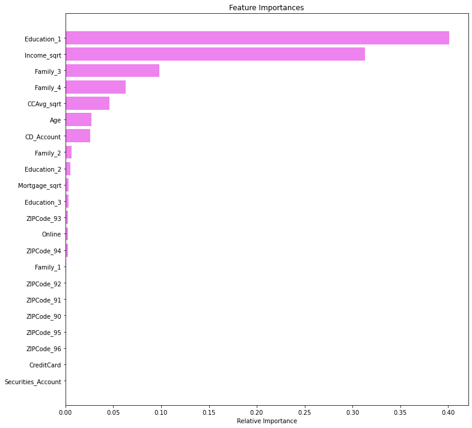

```python
importances = dTree.feature_importances_
indices = np.argsort(importances)

plt.figure(figsize=(12,12))
plt.title('Feature Importances')
plt.barh(range(len(indices)), importances[indices], color='violet', align='center')
plt.yticks(range(len(indices)), [feature_names[i] for i in indices])
plt.xlabel('Relative Importance')
plt.show()
```

According to the decision tree model, Education is the most important feature. This is followed by Income, then Family, CCAvg, Age, CD_Account and then Mortgage.

#### The above tree is very complex and has more chances of overfitting.

### Reducing overfitting

In general, the deeper you allow your tree to grow, the more complex your model will become because you will have more splits and it captures more information about the data and this is one of the root causes of overfitting Let's try Limiting the max_depth of tree to 3

```python
dTree1 = DecisionTreeClassifier(criterion = 'gini',max_depth=3,random_state=1)
dTree1.fit(X_train, y_train)
```

```
DecisionTreeClassifier(max_depth=3, random_state=1)
```

### Confusion Matrix - decision tree with depth restricted to 3

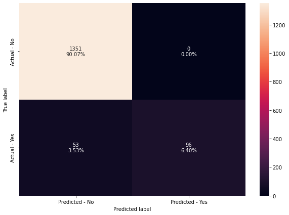

```python
make_confusion_matrix(dTree1, y_test)
```

```python
# Accuracy on train and test
print("Accuracy on training set : ",dTree1.score(X_train, y_train))
print("Accuracy on test set : ",dTree1.score(X_test, y_test))
# Recall on train and test
get_recall_score(dTree1)
```

```
Accuracy on training set :  0.9782857142857143
Accuracy on test set :  0.9646666666666667
Recall on training set :  0.770392749244713
Recall on test set :  0.6442953020134228
```

### Visualizing the Decision Tree with depth restricted to 3

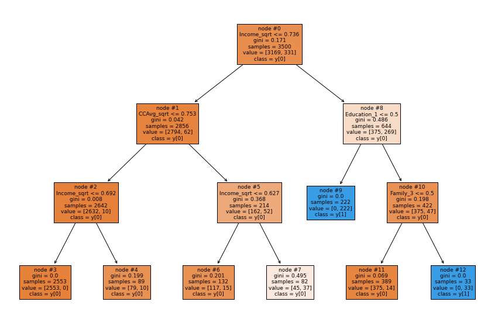

```python
plt.figure(figsize=(15,10))

tree.plot_tree(dTree1,feature_names=feature_names,filled=True,fontsize=9,node_ids=True,class_names=True)
plt.show()
```

```python
# Text report showing the rules of a decision tree -

print(tree.export_text(dTree1,feature_names=feature_names,show_weights=True))
```

```
|--- Income_sqrt <= 0.74
|   |--- CCAvg_sqrt <= 0.75
|   |   |--- Income_sqrt <= 0.69
|   |   |   |--- weights: [2553.00, 0.00] class: 0
|   |   |--- Income_sqrt >  0.69
|   |   |   |--- weights: [79.00, 10.00] class: 0
|   |--- CCAvg_sqrt >  0.75
|   |   |--- Income_sqrt <= 0.63
|   |   |   |--- weights: [117.00, 15.00] class: 0
|   |   |--- Income_sqrt >  0.63
|   |   |   |--- weights: [45.00, 37.00] class: 0
|--- Income_sqrt >  0.74
|   |--- Education_1 <= 0.50
|   |   |--- weights: [0.00, 222.00] class: 1
|   |--- Education_1 >  0.50
|   |   |--- Family_3 <= 0.50
|   |   |   |--- weights: [375.00, 14.00] class: 0
|   |   |--- Family_3 >  0.50
|   |   |   |--- weights: [0.00, 33.00] class: 1
```

The tree has become readable now but the recall on test set has not improved.

```python
# importance of features in the tree building ( The importance of a feature is computed as the
#(normalized) total reduction of the criterion brought by that feature. It is also known as the Gini importance )

print (pd.DataFrame(dTree1.feature_importances_, columns = ["Imp"], index = X_train.columns).sort_values(by = 'Imp', ascending = False))
```

```
                         Imp
Education_1         0.471323
Income_sqrt         0.366211
Family_3            0.115989
CCAvg_sqrt          0.046476
Age                 0.000000
ZIPCode_94          0.000000
Education_2         0.000000
Family_4            0.000000
Family_2            0.000000
Family_1            0.000000
ZIPCode_96          0.000000
ZIPCode_95          0.000000
ZIPCode_93          0.000000
Securities_Account  0.000000
ZIPCode_92          0.000000
ZIPCode_91          0.000000
ZIPCode_90          0.000000
Mortgage_sqrt       0.000000
CreditCard          0.000000
Online              0.000000
CD_Account          0.000000
Education_3         0.000000
```

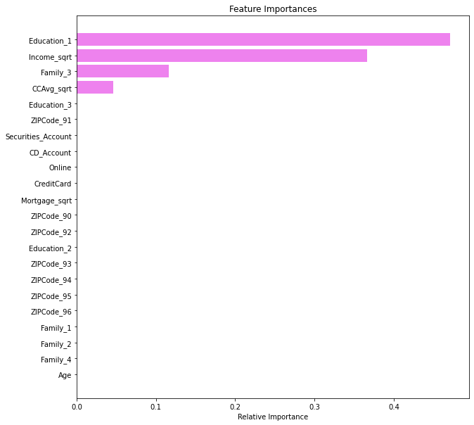

```python
importances = dTree1.feature_importances_
indices = np.argsort(importances)

plt.figure(figsize=(10,10))
plt.title('Feature Importances')
plt.barh(range(len(indices)), importances[indices], color='violet', align='center')
plt.yticks(range(len(indices)), [feature_names[i] for i in indices])
plt.xlabel('Relative Importance')
plt.show()
```

### Using GridSearch for Hyperparameter tuning of our tree model

```python
# Choose the type of classifier.
estimator = DecisionTreeClassifier(random_state=1)

# Grid of parameters to choose from
## add from article
parameters = {'max_depth': np.arange(1,10),
              'min_samples_leaf': [1, 2, 5, 7, 10,15,20],
              'max_leaf_nodes' : [2, 3, 5, 10],
              'min_impurity_decrease': [0.001,0.01,0.1]
             }

# Type of scoring used to compare parameter combinations
acc_scorer = metrics.make_scorer(metrics.recall_score)

# Run the grid search
grid_obj = GridSearchCV(estimator, parameters, scoring=acc_scorer,cv=5)
grid_obj = grid_obj.fit(X_train, y_train)

# Set the clf to the best combination of parameters
estimator = grid_obj.best_estimator_

# Fit the best algorithm to the data.
estimator.fit(X_train, y_train)
```

```
DecisionTreeClassifier(max_depth=5, max_leaf_nodes=10,
                       min_impurity_decrease=0.001, random_state=1)
```

### Confusion Matrix - decision tree with tuned hyperparameters

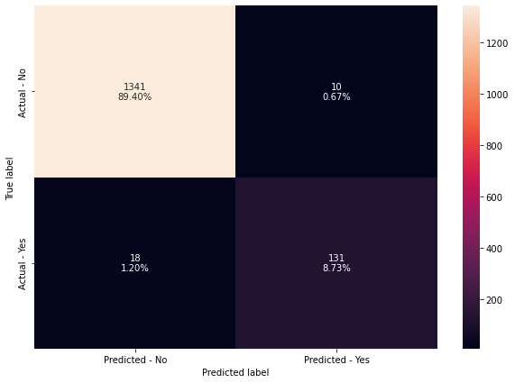

```python
make_confusion_matrix(estimator,y_test)
```

```python
# Accuracy on train and test
print("Accuracy on training set : ",estimator.score(X_train, y_train))
print("Accuracy on test set : ",estimator.score(X_test, y_test))
# Recall on train and test
get_recall_score(estimator)
```

```
Accuracy on training set :  0.9897142857142858
Accuracy on test set :  0.9813333333333333
Recall on training set :  0.9274924471299094
Recall on test set :  0.8791946308724832
```

Recall improved to 0.93 for training set and also improved for test set to 0.88 after hyper parameter tuning.

### Visualizing the Decision Tree with tuned hyperparameters

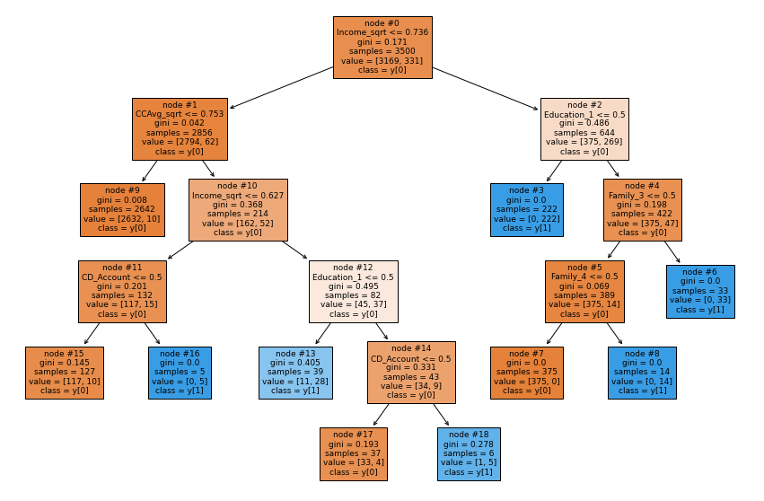

```python
plt.figure(figsize=(15,10))

tree.plot_tree(estimator,feature_names=feature_names,filled=True,fontsize=9,node_ids=True,class_names=True)
plt.show()
```

```python
# Text report showing the rules of a decision tree -

print(tree.export_text(estimator,feature_names=feature_names,show_weights=True))
```

```
|--- Income_sqrt <= 0.74
|   |--- CCAvg_sqrt <= 0.75
|   |   |--- weights: [2632.00, 10.00] class: 0
|   |--- CCAvg_sqrt >  0.75
|   |   |--- Income_sqrt <= 0.63
|   |   |   |--- CD_Account <= 0.50
|   |   |   |   |--- weights: [117.00, 10.00] class: 0
|   |   |   |--- CD_Account >  0.50
|   |   |   |   |--- weights: [0.00, 5.00] class: 1
|   |   |--- Income_sqrt >  0.63
|   |   |   |--- Education_1 <= 0.50
|   |   |   |   |--- weights: [11.00, 28.00] class: 1
|   |   |   |--- Education_1 >  0.50
|   |   |   |   |--- CD_Account <= 0.50
|   |   |   |   |   |--- weights: [33.00, 4.00] class: 0
|   |   |   |   |--- CD_Account >  0.50
|   |   |   |   |   |--- weights: [1.00, 5.00] class: 1
|--- Income_sqrt >  0.74
|   |--- Education_1 <= 0.50
|   |   |--- weights: [0.00, 222.00] class: 1
|   |--- Education_1 >  0.50
|   |   |--- Family_3 <= 0.50
|   |   |   |--- Family_4 <= 0.50
|   |   |   |   |--- weights: [375.00, 0.00] class: 0
|   |   |   |--- Family_4 >  0.50
|   |   |   |   |--- weights: [0.00, 14.00] class: 1
|   |   |--- Family_3 >  0.50
|   |   |   |--- weights: [0.00, 33.00] class: 1
```

```python
# importance of features in the tree building ( The importance of a feature is computed as the
#(normalized) total reduction of the 'criterion' brought by that feature. It is also known as the Gini importance )

print (pd.DataFrame(estimator.feature_importances_, columns = ["Imp"], index = X_train.columns).sort_values(by = 'Imp', ascending = False))
```

```
                         Imp
Education_1         0.447999
Income_sqrt         0.328713
Family_3            0.105394
Family_4            0.050317
CCAvg_sqrt          0.042231
CD_Account          0.025345
Age                 0.000000
ZIPCode_95          0.000000
Education_2         0.000000
Family_2            0.000000
Family_1            0.000000
ZIPCode_96          0.000000
ZIPCode_93          0.000000
ZIPCode_94          0.000000
Securities_Account  0.000000
ZIPCode_92          0.000000
ZIPCode_91          0.000000
ZIPCode_90          0.000000
Mortgage_sqrt       0.000000
CreditCard          0.000000
Online              0.000000
Education_3         0.000000
```

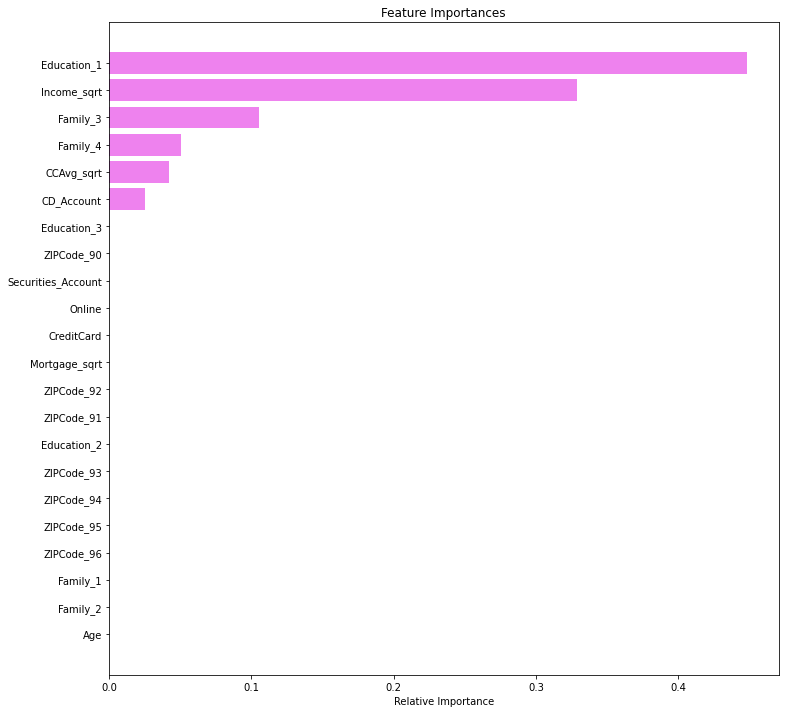

```python
importances = estimator.feature_importances_
indices = np.argsort(importances)

plt.figure(figsize=(12,12))
plt.title('Feature Importances')
plt.barh(range(len(indices)), importances[indices], color='violet', align='center')
plt.yticks(range(len(indices)), [feature_names[i] for i in indices])
plt.xlabel('Relative Importance')
plt.show()
```

Here, we see that the important features increased to include CD_Account. with the previous tree that was only pruned by setting the max depth to 3, it had only four important features. The decision tree with tuned hyperparameters showed better reults as the Recall for both train and test data improved. Also it included CD_Account as an important feature. Even though the top four important features remained the same, which are Education, Income, Family, and CCAvg.

### Cost Complexity Pruning

```python
clf = DecisionTreeClassifier(random_state=1)
path = clf.cost_complexity_pruning_path(X_train, y_train)
ccp_alphas, impurities = path.ccp_alphas, path.impurities
```

```python
pd.DataFrame(path)
```

|  | ccp_alphas | impurities |
| --- | --- | --- |
| 0 | 0.000000 | 0.000000 |
| 1 | 0.000188 | 0.000564 |
| 2 | 0.000268 | 0.001637 |
| 3 | 0.000273 | 0.003274 |
| 4 | 0.000275 | 0.003824 |
| 5 | 0.000359 | 0.004900 |
| 6 | 0.000381 | 0.005280 |
| 7 | 0.000381 | 0.005661 |
| 8 | 0.000381 | 0.006042 |
| 9 | 0.000476 | 0.006519 |
| 10 | 0.000527 | 0.007046 |
| 11 | 0.000582 | 0.007628 |
| 12 | 0.000593 | 0.008813 |
| 13 | 0.000641 | 0.011379 |
| 14 | 0.000769 | 0.014456 |
| 15 | 0.000882 | 0.017985 |
| 16 | 0.001552 | 0.019536 |
| 17 | 0.002333 | 0.021869 |
| 18 | 0.003024 | 0.024893 |
| 19 | 0.003294 | 0.028187 |
| 20 | 0.006473 | 0.034659 |
| 21 | 0.007712 | 0.042372 |
| 22 | 0.016154 | 0.058525 |
| 23 | 0.056365 | 0.171255 |

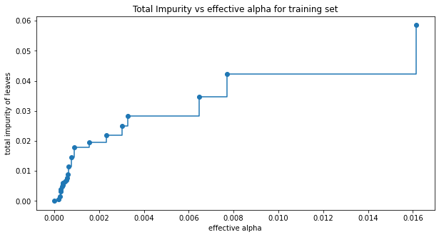

```python
fig, ax = plt.subplots(figsize=(10,5))
ax.plot(ccp_alphas[:-1], impurities[:-1], marker='o', drawstyle="steps-post")
ax.set_xlabel("effective alpha")
ax.set_ylabel("total impurity of leaves")
ax.set_title("Total Impurity vs effective alpha for training set")
plt.show()
```

```python
#Train a decision tree using effective alphas
clfs = []
for ccp_alpha in ccp_alphas:
    clf = DecisionTreeClassifier(random_state=1, ccp_alpha=ccp_alpha)
    clf.fit(X_train, y_train)
    clfs.append(clf)
print("Number of nodes in the last tree is: {} with ccp_alpha: {}".format(
      clfs[-1].tree_.node_count, ccp_alphas[-1]))
```

```
Number of nodes in the last tree is: 1 with ccp_alpha: 0.056364969335601575
```

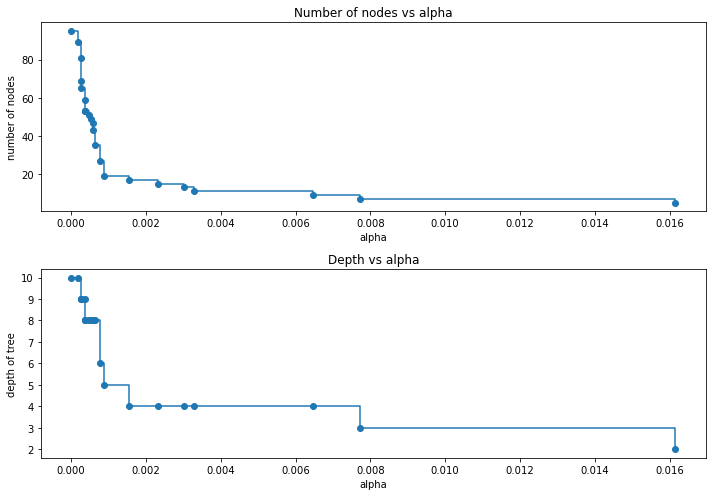

```python
#the number of nodes and tree depth decreases as alpha increases.
clfs = clfs[:-1]
ccp_alphas = ccp_alphas[:-1]

node_counts = [clf.tree_.node_count for clf in clfs]
depth = [clf.tree_.max_depth for clf in clfs]
fig, ax = plt.subplots(2, 1,figsize=(10,7))
ax[0].plot(ccp_alphas, node_counts, marker='o', drawstyle="steps-post")
ax[0].set_xlabel("alpha")
ax[0].set_ylabel("number of nodes")
ax[0].set_title("Number of nodes vs alpha")
ax[1].plot(ccp_alphas, depth, marker='o', drawstyle="steps-post")
ax[1].set_xlabel("alpha")
ax[1].set_ylabel("depth of tree")
ax[1].set_title("Depth vs alpha")
fig.tight_layout()
```

```python
train_scores = [clf.score(X_train, y_train) for clf in clfs]
test_scores = [clf.score(X_test, y_test) for clf in clfs]
```

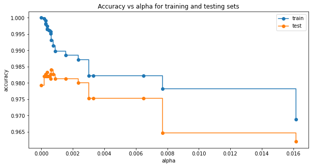

```python
fig, ax = plt.subplots(figsize=(10,5))
ax.set_xlabel("alpha")
ax.set_ylabel("accuracy")
ax.set_title("Accuracy vs alpha for training and testing sets")
ax.plot(ccp_alphas, train_scores, marker='o', label="train",
        drawstyle="steps-post")
ax.plot(ccp_alphas, test_scores, marker='o', label="test",
        drawstyle="steps-post")
ax.legend()
plt.show()
```

```python
index_best_model = np.argmax(test_scores)
best_model = clfs[index_best_model]
print(best_model)
print('Training accuracy of best model: ',best_model.score(X_train, y_train))
print('Test accuracy of best model: ',best_model.score(X_test, y_test))
```

```
DecisionTreeClassifier(ccp_alpha=0.0006414326414326415, random_state=1)
Training accuracy of best model:  0.9931428571428571
Test accuracy of best model:  0.984
```

```python
#We know that Accuracy is not best metric for our data, Lets use Recall as the metric.
#Recall for training set
recall_train=[]
for clf in clfs:
    pred_train3=clf.predict(X_train)
    values_train=metrics.recall_score(y_train,pred_train3)
    recall_train.append(values_train)
```

```python
#Recall for test set
recall_test=[]
for clf in clfs:
    pred_test3=clf.predict(X_test)
    values_test=metrics.recall_score(y_test,pred_test3)
    recall_test.append(values_test)
```

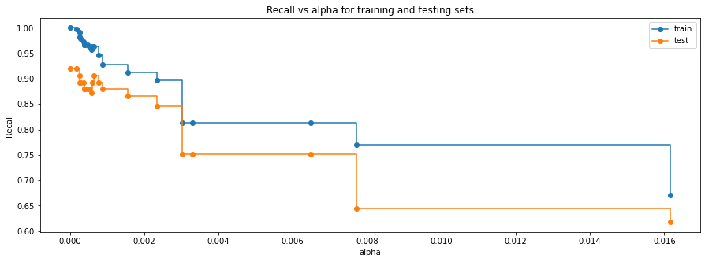

```python
fig, ax = plt.subplots(figsize=(15,5))
ax.set_xlabel("alpha")
ax.set_ylabel("Recall")
ax.set_title("Recall vs alpha for training and testing sets")
ax.plot(ccp_alphas, recall_train, marker='o', label="train",
        drawstyle="steps-post")
ax.plot(ccp_alphas, recall_test, marker='o', label="test",
        drawstyle="steps-post")
ax.legend()
plt.show()
```

```python
# creating the model where we get highest train and test recall
index_best_model = np.argmax(recall_test)
best_model = clfs[index_best_model]
print(best_model)
```

```
DecisionTreeClassifier(random_state=1)
```

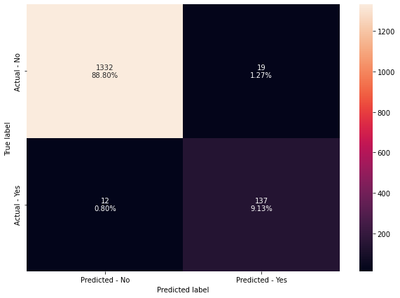

```python
make_confusion_matrix(best_model,y_test)
```

```python
# Recall on train and test for best_model
get_recall_score(best_model)
```

```
Recall on training set :  1.0
Recall on test set :  0.9194630872483222
```

### Visualizing the Decision Tree with cost complexity pruning

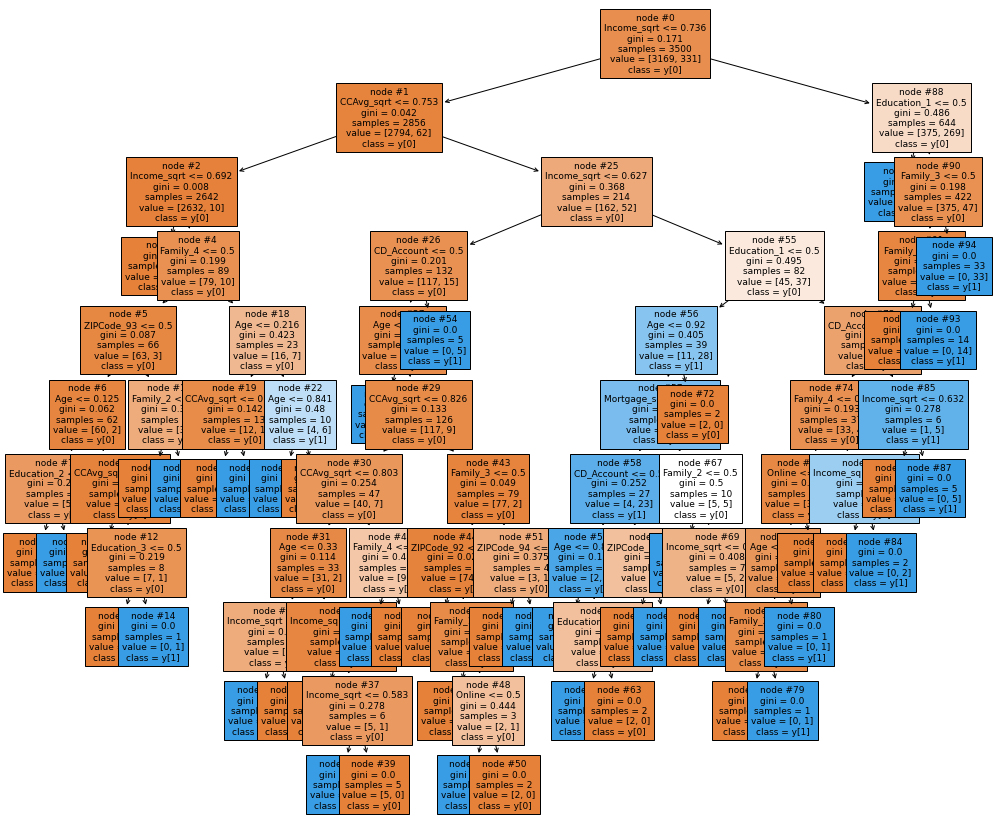

```python
plt.figure(figsize=(17,15))

tree.plot_tree(best_model,feature_names=feature_names,filled=True,fontsize=9,node_ids=True,class_names=True)
plt.show()
```

```python
# Text report showing the rules of a decision tree -

print(tree.export_text(best_model,feature_names=feature_names,show_weights=True))
```

```
|--- Income_sqrt <= 0.74
|   |--- CCAvg_sqrt <= 0.75
|   |   |--- Income_sqrt <= 0.69
|   |   |   |--- weights: [2553.00, 0.00] class: 0
|   |   |--- Income_sqrt >  0.69
|   |   |   |--- Family_4 <= 0.50
|   |   |   |   |--- ZIPCode_93 <= 0.50
|   |   |   |   |   |--- Age <= 0.13
|   |   |   |   |   |   |--- Education_2 <= 0.50
|   |   |   |   |   |   |   |--- weights: [5.00, 0.00] class: 0
|   |   |   |   |   |   |--- Education_2 >  0.50
|   |   |   |   |   |   |   |--- weights: [0.00, 1.00] class: 1
|   |   |   |   |   |--- Age >  0.13
|   |   |   |   |   |   |--- CCAvg_sqrt <= 0.65
|   |   |   |   |   |   |   |--- weights: [48.00, 0.00] class: 0
|   |   |   |   |   |   |--- CCAvg_sqrt >  0.65
|   |   |   |   |   |   |   |--- Education_3 <= 0.50
|   |   |   |   |   |   |   |   |--- weights: [7.00, 0.00] class: 0
|   |   |   |   |   |   |   |--- Education_3 >  0.50
|   |   |   |   |   |   |   |   |--- weights: [0.00, 1.00] class: 1
|   |   |   |   |--- ZIPCode_93 >  0.50
|   |   |   |   |   |--- Family_2 <= 0.50
|   |   |   |   |   |   |--- weights: [3.00, 0.00] class: 0
|   |   |   |   |   |--- Family_2 >  0.50
|   |   |   |   |   |   |--- weights: [0.00, 1.00] class: 1
|   |   |   |--- Family_4 >  0.50
|   |   |   |   |--- Age <= 0.22
|   |   |   |   |   |--- CCAvg_sqrt <= 0.68
|   |   |   |   |   |   |--- weights: [12.00, 0.00] class: 0
|   |   |   |   |   |--- CCAvg_sqrt >  0.68
|   |   |   |   |   |   |--- weights: [0.00, 1.00] class: 1
|   |   |   |   |--- Age >  0.22
|   |   |   |   |   |--- Age <= 0.84
|   |   |   |   |   |   |--- weights: [0.00, 6.00] class: 1
|   |   |   |   |   |--- Age >  0.84
|   |   |   |   |   |   |--- weights: [4.00, 0.00] class: 0
|   |--- CCAvg_sqrt >  0.75
|   |   |--- Income_sqrt <= 0.63
|   |   |   |--- CD_Account <= 0.50
|   |   |   |   |--- Age <= 0.08
```

[output cut: 87 more lines]

```
|   |   |   |   |   |--- Income_sqrt <= 0.63
|   |   |   |   |   |   |--- weights: [1.00, 0.00] class: 0
|   |   |   |   |   |--- Income_sqrt >  0.63
|   |   |   |   |   |   |--- weights: [0.00, 5.00] class: 1
|--- Income_sqrt >  0.74
|   |--- Education_1 <= 0.50
|   |   |--- weights: [0.00, 222.00] class: 1
|   |--- Education_1 >  0.50
|   |   |--- Family_3 <= 0.50
|   |   |   |--- Family_4 <= 0.50
|   |   |   |   |--- weights: [375.00, 0.00] class: 0
|   |   |   |--- Family_4 >  0.50
|   |   |   |   |--- weights: [0.00, 14.00] class: 1
|   |   |--- Family_3 >  0.50
|   |   |   |--- weights: [0.00, 33.00] class: 1
```

```python
# importance of features in the tree building ( The importance of a feature is computed as the
#(normalized) total reduction of the 'criterion' brought by that feature. It is also known as the Gini importance )

print (pd.DataFrame(best_model.feature_importances_, columns = ["Imp"], index = X_train.columns).sort_values(by = 'Imp', ascending = False))
```

```
                         Imp
Education_1         0.400952
Income_sqrt         0.313312
Family_3            0.098116
Family_4            0.062971
CCAvg_sqrt          0.045621
Age                 0.027126
CD_Account          0.025711
Family_2            0.006078
Education_2         0.005005
Mortgage_sqrt       0.003014
Education_3         0.002920
ZIPCode_93          0.002819
Online              0.002785
ZIPCode_94          0.002503
Family_1            0.000874
ZIPCode_92          0.000194
Securities_Account  0.000000
ZIPCode_95          0.000000
ZIPCode_96          0.000000
ZIPCode_91          0.000000
ZIPCode_90          0.000000
CreditCard          0.000000
```

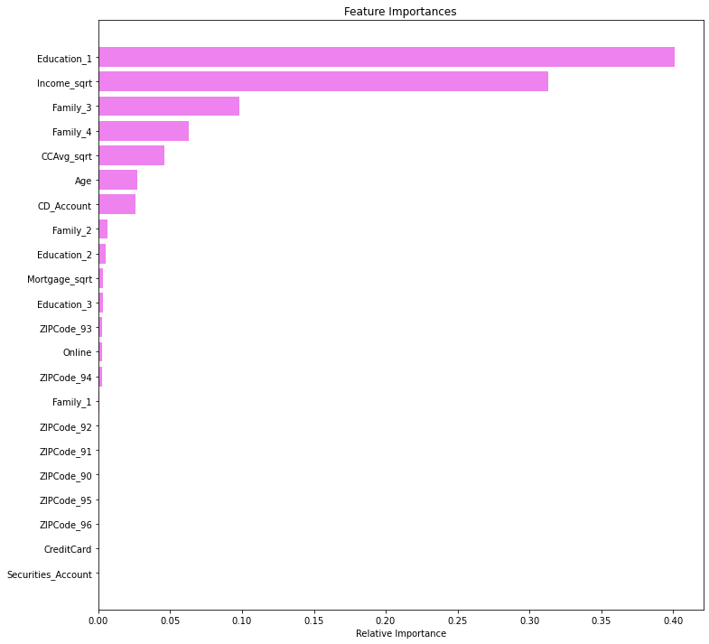

```python
importances = best_model.feature_importances_
indices = np.argsort(importances)

plt.figure(figsize=(12,12))
plt.title('Feature Importances')
plt.barh(range(len(indices)), importances[indices], color='violet', align='center')
plt.yticks(range(len(indices)), [feature_names[i] for i in indices])
plt.xlabel('Relative Importance')
plt.show()
```

Observation: We see here that the top 5 important features remained the same however, in this model we also got another feature that is Age. So now with this model we have 6 important features.

Education is the most important feature, with relative importance above 0.4. This is followed by Income with relative importance above 0.3. Then Family with realtive importance less than 0.2. Followed by CCAvg which is less than 0.1. CD_Account and Age are next with relative importance less than 0.05.